# Tarea 26/10: Análisis exploratorio de datos con ggplot2

## *Menstruacción*

Primero prendo las librerías

```r
library(tidyverse)
library(janitor)
```

Leo el csv sobre datos de consumo de productos de gestión menstrual y creo un objeto.

```r
menstruaccion <-
readr::read_csv("https://raw.githubusercontent.com/cienciadedatos/datos-de-miercoles/master/datos/2019/2019-12-04/menstruaccion.csv")
```

```r
menstru2 <- clean_names(menstruaccion)
```

Selecciono las variables que me interesan: *Categoría*, *precio por unidad* y *región*

```r
menstru3 <- select(menstru2, "categoria", "precio_por_unidad", "region")
```

Ahora que tengo los datos ordenados, a trabajar sobre la visualización

```r
library(ggplot2)
library(ggridges)
```

Para conocer la distribución del precio por unidad de productos de gestión menstrual por región, armo un gráfico de K Density, una versión suavizada del histograma.

Primero, a modo de prueba, saco la distribución del precio por unidad. El problema es que esto me toma toallitas y tampones en conjunto.

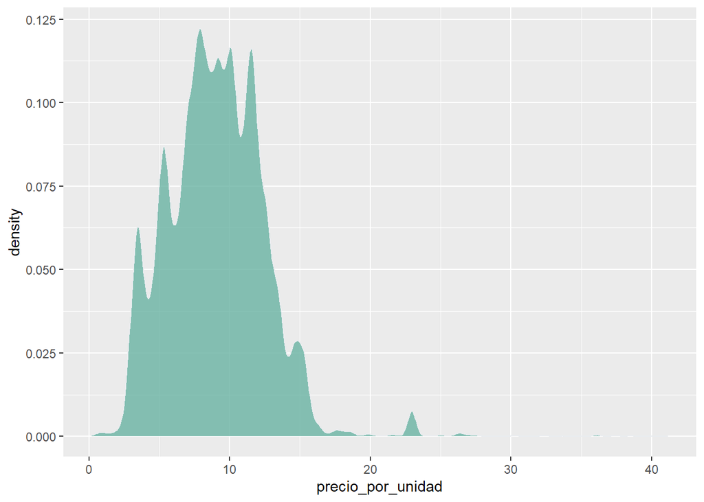

```r
ggplot(data=menstru3, aes(x=precio_por_unidad
                        )) +
    geom_density(fill="#69b3a2", color="#e9ecef", alpha=0.8)
```

Para separar toallitas de tampones le digo que me llene las densidades de acuerdo a la categoría. Determino como variable x al precio por unidad y como parámetro de relleno a la categoría.

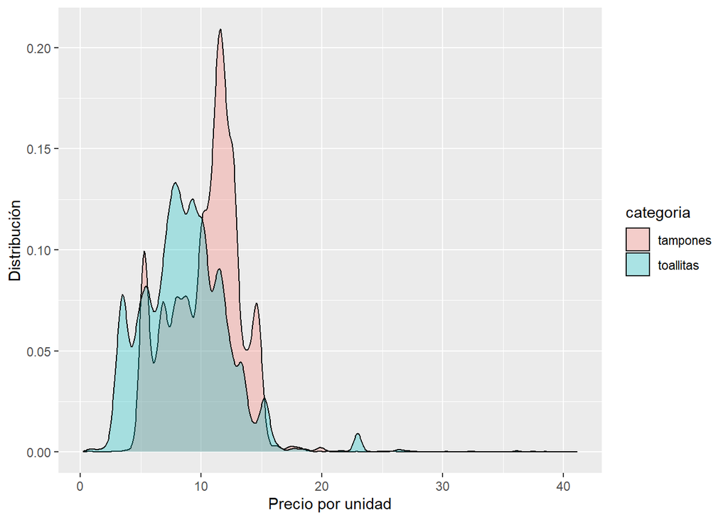

```r
ggplot(menstru3, aes(precio_por_unidad, fill= categoria)) +
         geom_density(alpha= .3) +
        labs(x= "Precio por unidad", y= "Distribución")
```

Ahora resta incorporar la variable región, añadiendolo como variable y. Quería probar si esta opción era posible usando el códico *geom_density* de ggplo2, pero no me devolvía lo mismo que el modelo así que usamos *geom_density_ridges* del paquete ggridges.

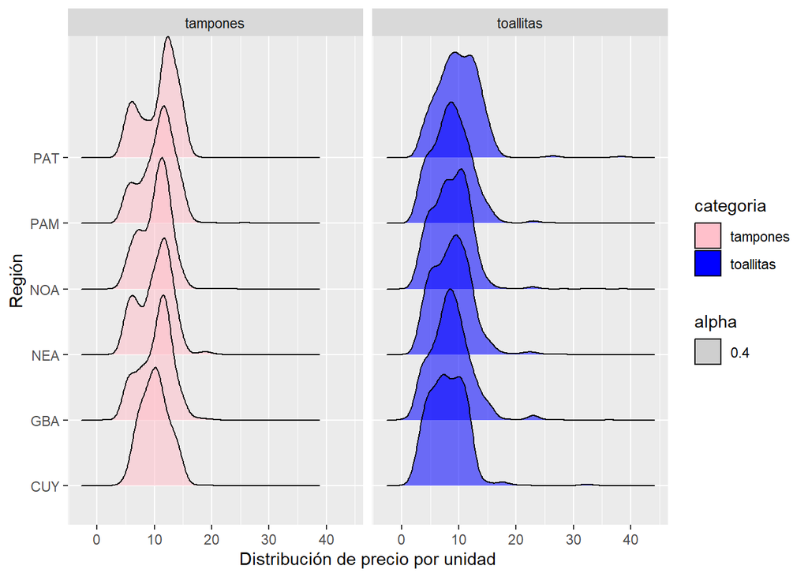

```r
ggplot(menstru3, aes(x = precio_por_unidad, y = region, fill = categoria, alpha= .4)) +
  geom_density_ridges(scale = 2, bandwidth = 1) +
  labs(x= "Distribución de precio por unidad", y= "Región") +
  scale_fill_manual(values = c("pink", "blue"))+
  facet_wrap(. ~ categoria)
```